# Basic Data Visualization with ggplot2

10/28/2019

## ggplot2 for Data Visualization

– skimr provides a simple summary of data

– ggplot2 as a grammar of graphics:

- Basic scatterplot
- Faceting for small multiples
- Loess and linear regression layers
- Reordering for easy comparisons

## ggplot2 for Data Visualization

– Typical repeated measures data: “sleepstudy”

- Reaction (reaction time)
- Days (day of participation)
- Subject (participant ID)

– Does sleep deprivation increase reaction times for people? in a uniform way?

## Useful Packages

– `library(skimr)` for skim

– `library(tidyverse)` for ggplot2, dplyr

## skimr to Summarize Data

```r
library(skimr)
library(lme4) # For the sleep study data
sleep.df = sleepstudy
skim(sleep.df)
```

```
## Skim summary statistics
##  n obs: 180
##  n variables: 3
##
## ── Variable type:factor ──────────────────────────────────────────────────────────────────────────────────────────────────────────────────
##  variable missing complete   n n_unique                         top_counts
##   Subject       0      180 180       18 308: 10, 309: 10, 310: 10, 330: 10
##  ordered
##    FALSE
##
## ── Variable type:numeric ─────────────────────────────────────────────────────────────────────────────────────────────────────────────────
##  variable missing complete   n   mean    sd     p0    p25    p50    p75
##      Days       0      180 180   4.5   2.88   0      2      4.5    7
##  Reaction       0      180 180 298.51 56.33 194.33 255.38 288.65 336.75
##    p100     hist
##    9    ▇▃▃▃▃▃▃▇
##  466.35 ▂▇▇▆▆▃▁▁
```

## Simple Scatterplot

### Mapping variables to aesthetic properties of geometric elements

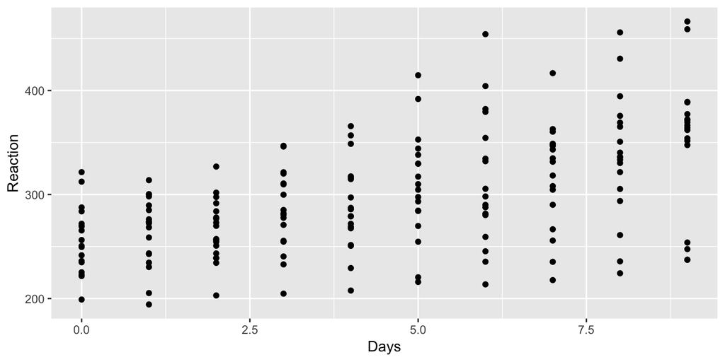

```r
library(ggplot2)

ggplot(data = sleep.df, mapping = aes(x = Days, y = Reaction)) +
  geom_point()
```

## Simple Scatterplot

### Setting aesthetic properties

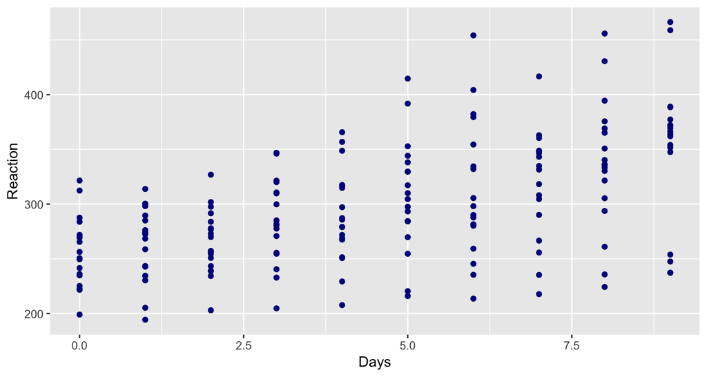

```r
ggplot(data = sleep.df, mapping = aes(x = Days, y = Reaction)) +
  geom_point(colour = "darkblue")
```

## Simple Scatterplot

### Layering geometric elements

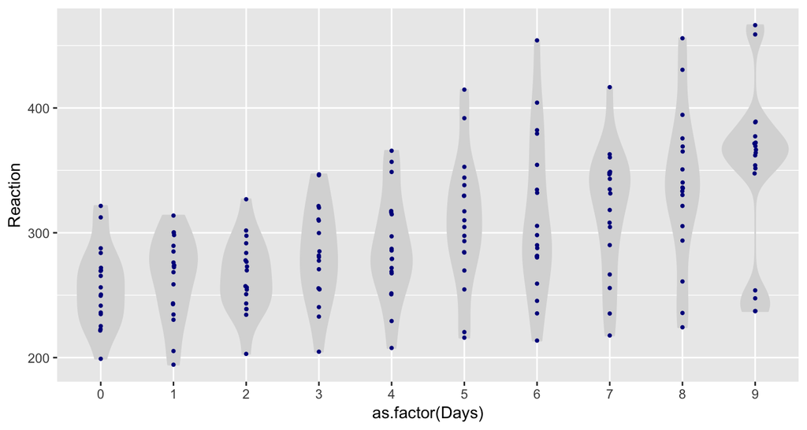

```r
ggplot(data = sleep.df, mapping = aes(x = as.factor(Days), y = Reaction)) +
  geom_violin(fill= "grey85", colour = "grey85") +
  geom_sina(colour = "darkblue", size = .7)
```

## Grouped Scatterplot with Linear Regression

### Slopes and intercepts both vary across people

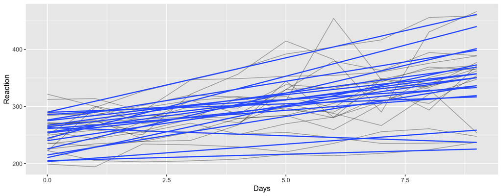

```r
ggplot(sleep.df, aes(x = Days, y = Reaction, group = Subject)) +
  geom_line(alpha = .33) +
  geom_smooth(method = "lm", se = FALSE, size = .8)
```

```r
## What happens when you don't identify the groups?
# ggplot(sleep.df, aes(Days, Reaction)) +
#   geom_point() +
#   geom_smooth(method = "lm", se = FALSE)
```

## Exercise

### Simple Scatterplot

–Replicate what we just showed in an R notebook – Create a Notebook: File>>New file>> R Notebook

– Load the lme4, skimr, and tidyverse packages

– Create the dataframe `sleep.df` by setting it equal to `sleepstudy`

– Use `skimr` to summarize the data

– Use ggplot2 to create simple scatterplot of reaction time and day, and set the color to `darkred`

– Divide code into blocks and add text to make understandable

## Faceted Scatterplot

### Small multiples to show individual responses

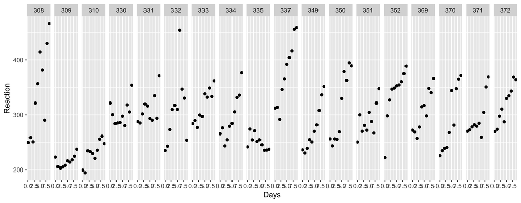

```r
ggplot(data = sleep.df, mapping = aes(x = Days, y = Reaction)) +
  geom_point() +
  facet_grid(.~Subject)
```

## Faceted Scatterplot with Loess Fit

### A layer of loess fits shows a linear model doesn’t fit all participants

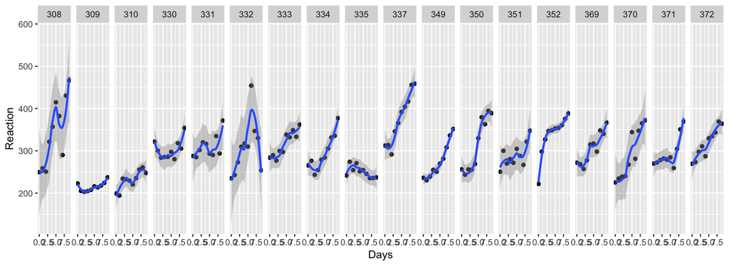

```r
ggplot(sleep.df, aes(Days, Reaction)) +
  geom_point() +
  geom_smooth(method = "loess") +
  facet_grid(.~Subject)
```

## Faceted Scatterplot with Linear Regression

### A linear model shows slopes and intercepts differ

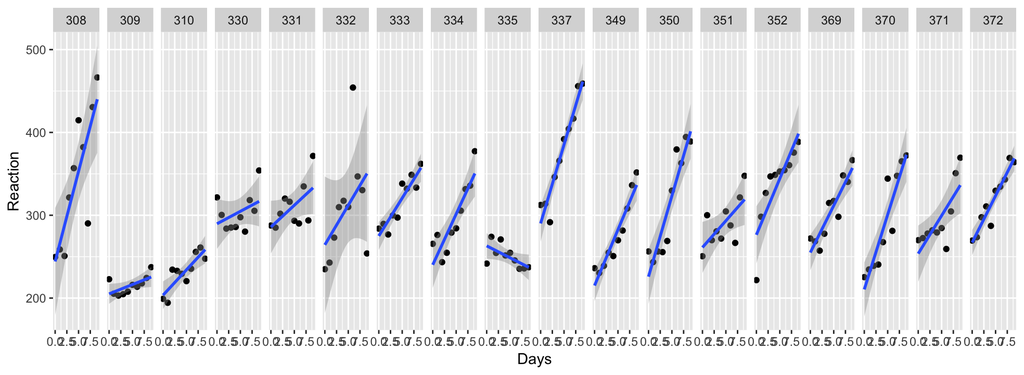

```r
ggplot(sleep.df, aes(Days, Reaction)) +
  geom_point() +
  geom_smooth(method = "lm") +
  facet_grid(.~Subject)
```

## Faceted Scatterplot with Linear Regression

### Subjects ordered by mean reaction time

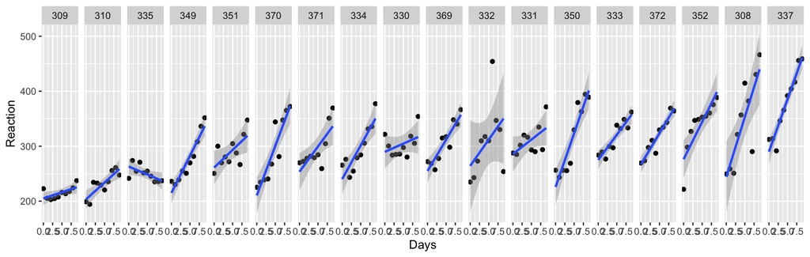

```r
ggplot(sleep.df, aes(Days, Reaction)) +
  geom_point() +
  geom_smooth(method = "lm") +
  facet_grid(.~reorder(x = Subject, X = Reaction, FUN = mean))
```

## Exercise

### Replicate the faceted scatterplot by adding it to your R notebook

– Create a scatterplot faceted by `Subject`

– Try `+ facet_grid(.~Subject)` and `+ facet_grid(Subject~.)`

– Add a layer of `+ geom_smooth()`

– Order Subjects by standard deviation of `Reaction`

## Visualization: A critical first step for any modeling

– Layering to show data and model:  
Loess and linear regression layers

– Loess and linear regression layers

– Faceting for small multiples

– Reordering for easy comparisons

[figure not shown]